```python
%%javascript
IPython.OutputArea.prototype._should_scroll = function(lines) {
    return false;
}
```

# Post Goals:

1. Introduction to A/B Testing.
2. Demonstrate how to carry out an A/B test using \(\chi^{2} \) test statistic in Python.

# Post Overview.

1. Introduction to A/B Testing.
2. Example Case Details.
3. Introduction to \(\chi^{2} \) Test for Association.
4. Conducting an A/B Test using \(\chi^{2} \) test statistic Python..

# Introduction to A/B Testing.

**What is A/B Testing?**

- A/B testing is also called split testing, bucket testing, and split-run testing.
- A/B testing refers to a randomized experimental technique used to compare the affects of a user's behavior to two versions of a single variable (A and B).
- A/B testing is used to determine whether a version brings improvements to a chosen business metric.
- A/B testing is commonly conducted on online, mobile, application software and by large social media sites.
- A/B testing are useful at understanding how online features affect user engagement and satisfaction.
- A/B testing in web development has been routinely conducted since the 2000s, and since then A/B testing is used in more complex experiments, and is an essential knowhow for any data scientist.
- The goal of A/B testing is to challenge an existing version of a web feature (A) with a new one (B), by randomly splitting traffic and comparing metrics on each of the splits.

**A/B Test Case Example**

[figure not shown]

- A company is currently using version A of a landing page (control).
- The company is considering a new landing page arrangement (treatment) and want test if the new layout increases key business metrics.
- The metrics the company will test include:
  - Average time spent on landing page.
  - Conversion rate (proportion of sessions that result in a transaction).
- Using an A/B test will help the company make an informed decision based on empirical data and statistical testing.

**Common Business Metrics Tested**

- **Engagement metrics:** are a set of variables that include time spent on a site, unique visitors, page views, page/scroll depth, number of people who visit a page, and click-through rate, to name a few. Some of these are calculated using averages.
- **Conversion Rates:** measures how many visitors performed a desired action, and includes making a purchase, signing up for an email list, filling out a form, completing a survey, subscribing to a service, or adding a comment or review.  
  \[Conversion\ Rate = {\frac{Action\ completed}{Site\ Visitors} }\]
- **Average Time Spent (Session Duration):** is measures that describes the average time visitors spent on the website as a whole (Average Session/Time spent), or the average time visitors spent on a specific page (Average time on page).  
  \[Average\ Time = {\frac{\Sigma(Time\ spent\ by\ visitor)}{Total\ Number\ of\ Visitors)} }\]
- **Bounce Rates:** is a type of engagement metric that measures how many visitors enter the landing page but leave without continuing to view other pages in the same site.  
  \[Bounce\ Rate = R_{b}\ = {\frac{T_{v}}{T_{e}} } \] \[T_{v} = Total\ one\ page\ visits\] \[T_{e} = Total\ entrance\ visits\]
- **Exit Rates:** is a type of engagement metric that measures the number of times visitors have left a site from a single page. The page's exit rate indicates how often visitors exit from it after visiting any number of pages.  
  \[Exit\ Rate = R_{e}\ = {\frac{T_{exits}}{T_{views}} } \] \[T_{exits} = Total\ exits\ from\ page\] \[T_{views} = Total\ visits\ to\ page\]

**Common test statistics**

- A/B Testing includes statistical hypothesis testing.
- The test metric typically dictates which test statistics to use.

| Metric | Assumed Distribution | Standard Test | Alternative Test |
| --- | --- | --- | --- |
| Conversion Rate | Gaussian or Binomial | Z-test | Chi-squared test |
| Average Revenue per user | Gaussian | Welch's t-test (unpaired t-test) | Student's t-test |
| Time spent on website | Gaussian | Z-test | Chi-squared test |
| Number of each product purchased | Multinomial | Chi-squared test |  |

# Case Details

## This post will demonstrate how to conduct an A/B test:

- using python
- will evaluate the affects of the A/B test on conversion rate.
- use the \(\chi^{2} \) test statistics to determine significance.

**Chi-Square Test for Association Assumptions**

- Three assumptions must be met to conduct a chi-square test for association:
  1. You have categorical variables that are either nominal or ordinal. In our example we have nominal and binary categories (converted or not converted). Ordinal just refers to categorical data that has order (cold, warm, hot).
  2. You have independence of observations. This means that there is no relationship between the observations in the group and between the categories in the group. In other words, you need to have different participants in each group. We do not have a user that visited both landing pages. They were either directed to version A or version B.
  3. All cells should have expected counts greater than five.

## The Data:

- The company in this example provided the following data for the analysis.

| Version | Traffic split |
| --- | --- |
| Landing A | Landing B |
| 6000 | 4000 |

[output not shown]

# Introduction to \(\chi^{2} \) Test for Association.

**\(\chi^{2} \) Test for Association:**

- **Test Statistic Selection:** In this example we will use the \(\chi^{2} \) Test for Association.
- **Test Statistic Selection Rationale:** The Chi-square tests for association between two nominal (categorical) variables, to determine if they are statistically independent. In other words, this test allows us to determine if the our variables conversion, and landing page version, are statistically independent.

**Assumptions for using Chi-Square Test for Association**

- Three assumptions must be met to conduct a chi-square test for association:
  1. You have categorical variables that are either nominal or ordinal. In our example we have nominal and binary categories (converted or not converted). Ordinal just refers to categorical data that has order (cold, warm, hot).
  2. You have independence of observations. This means that there is no relationship between the observations in the group and between the categories in the group. In other words, you need to have different participants in each group. We do not have a user that visited both landing pages. They were either directed to version A or version B.
  3. All cells should have expected counts greater than five.

**Hypothetical \(\chi^{2} \) Example:**

- **Example:** Exercise and Heart Disease.
  - **Tested association:** Determine if there is an association between exercise and the presence of heart disease.
  - **Data types:** Both variables are categorical (aka nominal) and binomial.
  - **Variable 1 (exercise):** yes or no (binomial)
  - **Variable 2 (presence of heart disease):** yes or no (binomial)
  - **Data aggregated values:** Counts
  - **Data presentation:** typically a frequency table that aggregates (counts) the number of individuals that fall in each bucket or cell.

**This Post \(\chi^{2} \) Example:**

**Understanding Chi-Square Test for Association Assumptions**

- Chi-square test for association between two nominal variables by by comparing the observed frequencies to the frequencies we would expect if there was no association between the two nominal variables.
- This means we would have our data frequency table, and we would then determine calculate an estimator from our pooled observations, and calculate an expected frequency table. This process will be demonstrated in the next section of this post.
- The expected frequencies are predicated on there being no association.
- The greater the association between the two categories, the greater the observed frequencies will differ from the expected frequencies.
- The less the two categories are associated, the closer the observed frequencies will be to the expected frequencies.
- Chi-square test produces a statistic based on the overall "amount" of difference between the expected and observed frequencies and is described as: \[\chi_{2} = \Sigma\frac{(\mathit{f}_{observed} - \mathit{f}_{expected})^{2}}{\mathit{f}_{expected}} \]  
  \(\mathit{f}_{observed} \) is the observed frequency from the observed counts in the cells  
  \(\mathit{f}_{expected} \) is the expected frequency if NO relationship existed between the two categories (converted not converted).
- The larger the difference between the observed frequencies to the expected frequencies, will result in a larger test statistic.
- The larger the test statistic, the greater the association and the more likely a statistically significant result.

# Conducting an A/B Test using Python - Process Overview

1. State the Null Hypotheis \(H_{o} \).
2. State the Alternative Hypotheis \(H_{a} \).
3. Select a Significance Level \(\alpha \).
4. Model \(H_{o} \) using Binomial Distribution \(B(1,p)\) and \(\chi^{2}\) test.
5. Determine the likelyhood of \(H_{o} \) by calculating the p-value according to the \( \chi^{2}\) law.
6. Interpret results.

# State the Null Hypothesis \(H_{o} \)

**Null Hypothesis**

- Is a statistical hypothesis that assumes that the observation from the data is due to a chance factor and proposes no significant difference exists between a set of given observations.
- In this example we are using the Chi-Square test for association.
- Chi-Square test for independence, also called Pearson's chi-square test or the chi-square test of association, and is used to discover if there is a relationship between two categorical variables.
- In this example, the Null Hypothesis \(H_{o} \) states that the conversion rates for the landing page A and B are the same.

# State the Alternative Hypotheis \(H_{a} \)

**Alternative Hypothesis**

- Is a statistical hypothesis that assumes that the observation from the data is due to a chance factor and proposes that there is a significant difference between a set of given observations.
- In this example, the Alternative Hypothesis \(H_{a} \) states that there **is a difference** in the conversation rates between visitors that were directed to landing page A versus landing page B.

# Select a Significance Level \(\alpha \)

**Levels of Significance \(\alpha \)**

# Model \(H_{o} \) using Binomial Distribution \(B(1,p)\) and \(\chi^{2}\) test

**Modeling the \(H_{o} \) using \(\chi^{2}\) test**

- To reiterate the hypothesis
  - \(H_{o} \): No difference in conversion rates between landing page versions.
  - \(H_{a} \): There is a difference in the conversion rates between landing page versions.
- \(\chi^{2}\) test compares the distribution of multinomial outcomes, but this also allows for binary cases, such as in this example (converted or did not convert).

**Calculate and estimator.**

- Derive the estimator for the convertion rate using the formula: \[\hat{p} = \frac{O_{A1} + O_{B1}}{O_{A0}+O_{A1}+O_{B0}+O_{B1}} \]  
  \(O_{A0} \): Web landing version A, no conversion  
  \(O_{A1} \): Web landing version A, with conversion  
  \(O_{B0} \): Web landing version B, no conversion  
  \(O_{B1} \): Web landing version B, with conversion

**Calculate theoretical outcomes table.**

- Multiply the column with the number of instances in the observed contingency (frequency) table with the derived estimator \(\hat{p} \).
- This will give you the expected theoretical conversion and non conversion counts by landing page if \(H_{0} \) is true.

**Calculate the squared relative distance between the theoretical and observed distributions.**

- \[D = \Sigma_{landing\ page\ version\ \in\{A,B\},conversion\in\{0,1\}} \frac{(Observed_{version,conversion} - Theoretical_{version,conversion})^{2}}{Theoretical_{version,conversion}} \]
- **D** represents the relative distance between the theoretical and the observed distribution, and according to Pearson's theorem, the \(H_{0} \) follows a \(\chi^{2} \) probability law with a single degree of freedom.

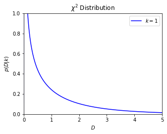

```python
import numpy as np
from scipy.stats import chi2
from matplotlib import pyplot as plt

#------------------------------------------------------------
# Define the distribution parameters to be plotted
k = 1
mu = 0
x = np.linspace(-1, 20, 1000)

#------------------------------------------------------------
# plot the distributions
fig, ax = plt.subplots(figsize=(5, 3.75))
dist = chi2(k, mu)
plt.plot(x, dist.pdf(x), c='blue',
             label=r'$k=%i$' % k)

plt.xlim(0, 5)
plt.ylim(0, 1)

plt.xlabel('$D$')
plt.ylabel(r'$p(D|k)$')
plt.title(r'$\chi^2\ \mathrm{Distribution}$')

plt.legend()
plt.show()
```

# Determine the likelihood of \(H_{o} \) by calculating the p-value according to the \( \chi^{2}\) law

**Pythonic process for determining the likelihood.**  
This step consists in computing the observed distance between the observed and theoretical and deriving its corresponding p-value according to the \(\chi^{2} \) law.

```python
# Code to calculate the p-value for our test
import numpy as np
from scipy.stats import chi2

T = np.array([102, 68, 5898, 3932])
O = np.array([90, 80, 5910, 3920])

D = np.sum(np.square(T-O)/T)

pvalue = chi2.sf(D, df=1)

print("distance d: {0}\np-value: {1}".format(D,pvalue))
```

```
distance d: 3.590449404583807
p-value: 0.05811252579106675
```

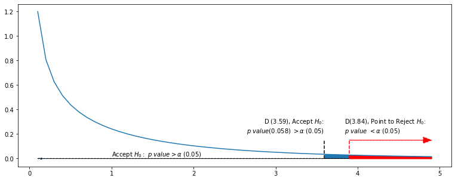

```python
plt.figure(figsize=(13,5)) # figure size

# Plot the result of our hypothesis test
d = np.arange(0, 5, 0.1)
plt.plot(d, chi2.pdf(d, df=1))
plt.vlines(D, 0, 0.15, colors="black", linestyle="dashed")
plt.fill_between(d[d>D], chi2.pdf(d[d>D], df=1))
plt.text(D, 0.21, r'D (3.59), Accept $H_{0}$:''\n'r'$p\ value (0.058)\ > \alpha\ (0.05)$', fontsize=10, ha='right')

# area where Null Hypothesis would be rejected
d_sig = 3.84 # this is the point in which a result would be significant at an alpha of 0.05 with degree of freedom = 1
plt.vlines(d[d>d_sig][0], 0, 0.15, colors="red", linestyle="dashed")
plt.fill_between(d[d>d_sig], chi2.pdf(d[d>d_sig], df=1), color="red")
plt.arrow(x=d[d>d_sig][0], y=0.15, dx=1, dy=0, shape='full', head_length= 0.1, head_width=0.05, length_includes_head=True, color="red", linestyle='dashed')
plt.text(d_sig, 0.21, r'D(3.84), Point to Reject $H_{0}$:''\n'r'$p\ value\ < \alpha\ (0.05)$', fontsize=10)

# area to accept the Null Hypothesis
plt.text(1, 0.02, r'Accept $H_{0}:\ p\ value > \alpha\ (0.05)$', fontsize=10)
plt.arrow(x=d[d>d_sig][0], y=0, dx=-3.8, dy=0, shape='full', head_length= 0.05, head_width=0.01, length_includes_head=True, linestyle='--')
plt.show()
```

# Interpret results

**Which hypothesis is support by the data?**